# Description

Siva

2023-10-13

## Supermarket Sales Data Analysis

Categorical variables are branch, city, type of customer, customer gender and kind of product they buy and method of payment. Quantitative variables are cost of single unit, quantity, 5% markup, revenue, cogs (cost of goods sold) and gross income.

## Descriptive Statistics

```r
smdata <- read.csv('data/supermarket_sales.csv')
summary(smdata)
```

```
##   invoice_id           branch              city           customer_type
##  Length:1000        Length:1000        Length:1000        Length:1000
##  Class :character   Class :character   Class :character   Class :character
##  Mode  :character   Mode  :character   Mode  :character   Mode  :character
##
##
##
##  gender_customer    product_line         unit_cost        quantity
##  Length:1000        Length:1000        Min.   :10.08   Min.   : 1.00
##  Class :character   Class :character   1st Qu.:32.88   1st Qu.: 3.00
##  Mode  :character   Mode  :character   Median :55.23   Median : 5.00
##                                        Mean   :55.67   Mean   : 5.51
##                                        3rd Qu.:77.94   3rd Qu.: 8.00
##                                        Max.   :99.96   Max.   :10.00
##   X5pct_markup        revenue            date               time
##  Min.   : 0.5085   Min.   :  10.68   Length:1000        Length:1000
##  1st Qu.: 5.9249   1st Qu.: 124.42   Class :character   Class :character
##  Median :12.0880   Median : 253.85   Mode  :character   Mode  :character
##  Mean   :15.3794   Mean   : 322.97
##  3rd Qu.:22.4453   3rd Qu.: 471.35
##  Max.   :49.6500   Max.   :1042.65
##  payment_method          cogs            gm_pct       gross_income
##  Length:1000        Min.   : 10.17   Min.   :4.762   Min.   : 0.5085
##  Class :character   1st Qu.:118.50   1st Qu.:4.762   1st Qu.: 5.9249
##  Mode  :character   Median :241.76   Median :4.762   Median :12.0880
##                     Mean   :307.59   Mean   :4.762   Mean   :15.3794
##                     3rd Qu.:448.90   3rd Qu.:4.762   3rd Qu.:22.4453
##                     Max.   :993.00   Max.   :4.762   Max.   :49.6500
##      rating
##  Min.   : 4.000
##  1st Qu.: 5.500
##  Median : 7.000
##  Mean   : 6.973
##  3rd Qu.: 8.500
##  Max.   :10.000
```

## Univariate Data Exploration

### Histogram plots

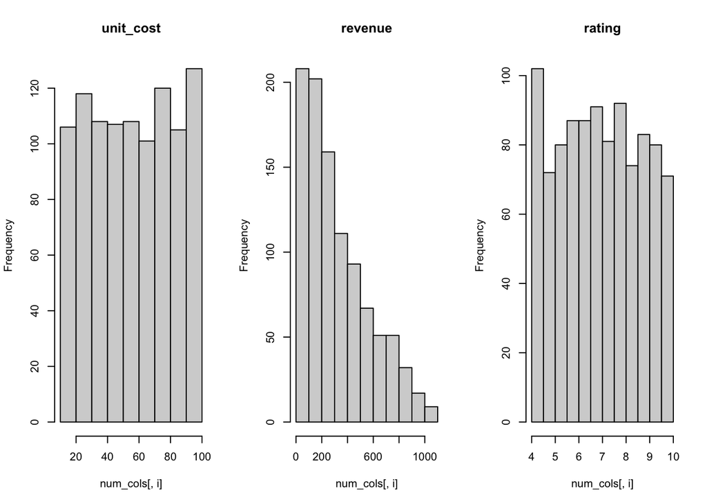

### Boxplots

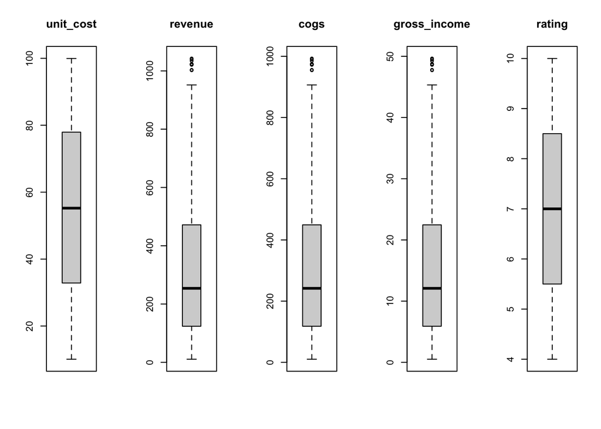

## Categorical Variables Analysis

```r
table(smdata$branch)
```

```
##
##   A   B   C
## 340 332 328
```

```r
table(smdata$city)
```

```
##
##  Mandalay Naypyitaw    Yangon
##       332       328       340
```

```r
table(smdata$customer_type)
```

```
##
## Member Normal
##    501    499
```

```r
table(smdata$gender_customer)
```

```
##
## Female   Male
##    501    499
```

```r
table(smdata$product_line)
```

```
##
## Electronic accessories    Fashion accessories     Food and beverages
##                    170                    178                    174
##      Health and beauty     Home and lifestyle      Sports and travel
##                    152                    160                    166
```

```r
table(smdata$payment_method)
```

```
##
##        Cash Credit card     Ewallet
##         344         311         345
```

## Bivariate Analysis

### City Vs Product line

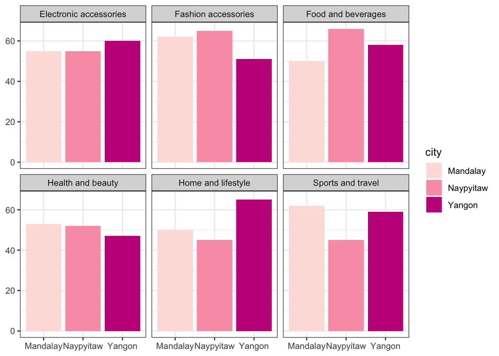

```r
library(ggplot2)
pink = c("#fde0dd","#fa9fb5","#c51b8a")

cpl <- ggplot(smdata) +
  geom_bar(aes(city,fill = city)) +scale_fill_manual(values = c(pink))+
  xlab(NULL) +
  ylab(NULL)+ facet_wrap(~product_line)+theme_bw()
cpl
```

### Customer Gender Vs Product Line

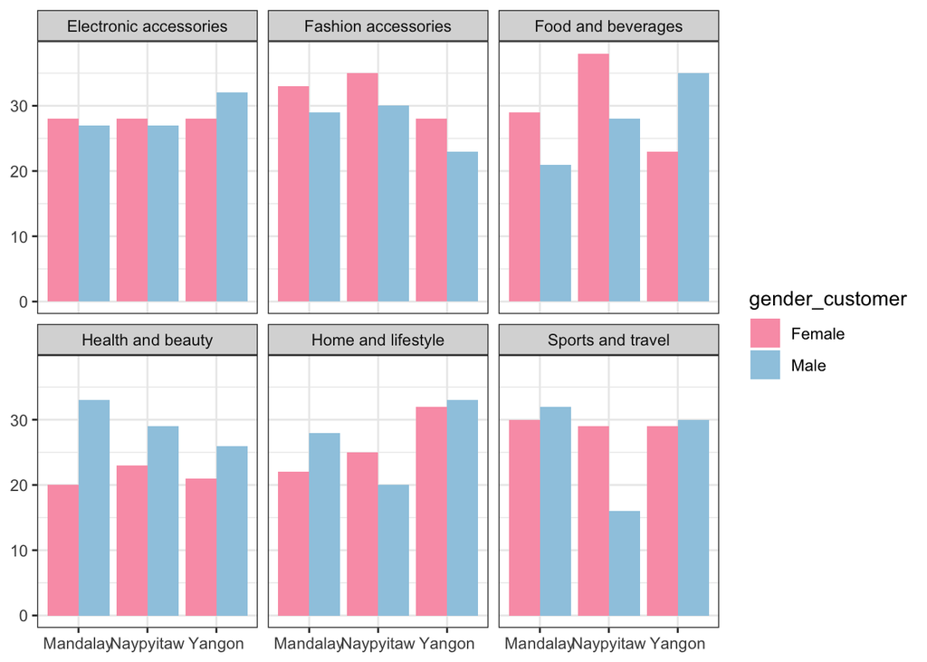

```r
blue = c("#deebf7","#9ecae1","#3182bd")
cgpl =  ggplot(smdata) +
  geom_bar(mapping=aes(city,fill = gender_customer),position="dodge") +
  scale_fill_manual(values = c("#fa9fb5","#9ecae1"))+xlab(NULL) +
  ylab(NULL)+ facet_wrap(~product_line)+theme_bw()

cgpl
```

### Customer Gender and Product line based on Payment Method

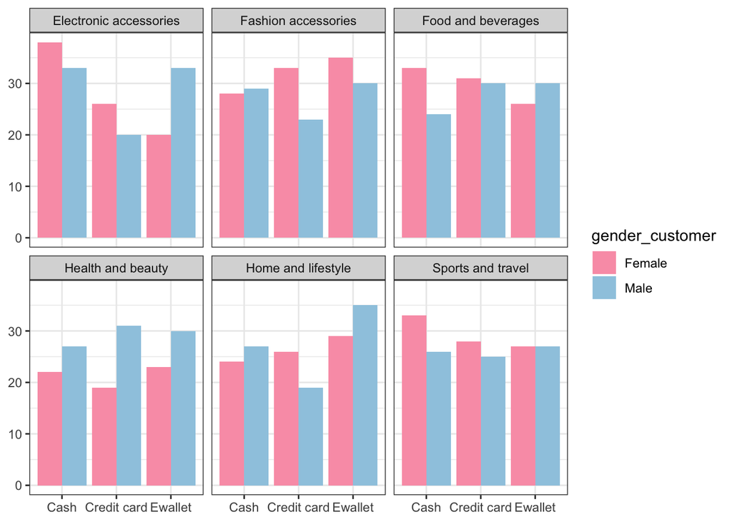

```r
gp = ggplot(smdata) + geom_bar(mapping=aes(payment_method,fill = gender_customer),position="dodge") +
  scale_fill_manual(values = c("#fa9fb5","#9ecae1"))+xlab(NULL) +
  ylab(NULL)+ facet_wrap(~product_line)+theme_bw()

gp
```

## Observations and Conclusions

On observing the supermarket sales data it is found that there are no missing values in the dataset and outliers had been spotted in revenue, cogs and gross income variables. Almost male and female customers are in equal proportion. Equal amounts of data were recorded across the three cities, members and non members are almost equal. The catagories of products were equally proportional.

In Yangon city the sales of electronics and accessories, home and lifestyle goods was highest. Health, beauty and fashion accessories sales was the least in this city in 2019.

In Naypyitaw city ranks first in the sales of food and beverages and ranks last in the sales of sports and travel ( also in home and lifestyle) in the year 2019.

The Mandalay city is just the opposite of Naypyitaw city because it ranks first in sales of sports and travel city and ranks last in sales of food and beverages. Otherwise it catches with Naypyitaw city in the sales of other products.

Mandalay city women buy mostly fashion accessories and men buy health and beauty goods mostly in 2019.